# Notebook para el tutorial de python

```python
import numpy as np
import matplotlib.pyplot as plt
import os
import cv2
import csv
import math

from nilearn import plotting
from nilearn.plotting.cm import _cmap_d as nilearn_cmaps
from nilearn.plotting import show

import nibabel as nib
from nibabel.testing import data_path

import nilearn.masking
```

```python
np.set_printoptions(precision=2, suppress=True)
data_path = 'data-tutorial'

# Cogemos los nombres de los diferentes archivos de nuestra carpeta data-tutorial que vamos a necesitar
PET_filename = 'sub-B10709603_ses-m00_AV1451.avg.nii'

T1_filename = 'sub-B10709603_ses-m00_T1.nii'

Mask_filename = 'sub-B10709603_ses-m00_T1_mask.nii'

Atlas_filename = 'sub-B10709603_ses-m00_desikanAtlas.nii'
```

## A continuación vamos a trabajar con el PET

Cargamos la imagen y vemos un poco el contenido del header, que contiene los metadatos del archivo

```python
pet_img = nib.load(os.path.join(data_path, PET_filename))
print(pet_img.header)
```

```
<class 'nibabel.nifti1.Nifti1Header'> object, endian='<'
sizeof_hdr      : 348
data_type       : b''
db_name         : b''
extents         : 0
session_error   : 0
regular         : b''
dim_info        : 0
dim             : [  3 128 128  47   1   1   1   1]
intent_p1       : 0.0
intent_p2       : 0.0
intent_p3       : 0.0
intent_code     : none
datatype        : float32
bitpix          : 32
slice_start     : 0
pixdim          : [-1.    2.73  2.73  3.27  0.    1.    1.    1.  ]
vox_offset      : 0.0
scl_slope       : nan
scl_inter       : nan
slice_end       : 0
slice_code      : unknown
xyzt_units      : 10
cal_max         : 0.0
cal_min         : 0.0
slice_duration  : 0.0
toffset         : 0.0
glmax           : 0
glmin           : 0
descrip         : b'FreeSurfer Jul 23 2020'
aux_file        : b''
qform_code      : scanner
sform_code      : scanner
quatern_b       : 0.0
quatern_c       : 1.0
quatern_d       : 0.0
qoffset_x       : 173.63281
qoffset_y       : -173.63281
qoffset_z       : -164.4202
srow_x          : [ -2.73   0.     0.   173.63]
srow_y          : [   0.      2.73    0.   -173.63]
srow_z          : [   0.      0.      3.27 -164.42]
intent_name     : b''
magic           : b'n+1'
```

En lugar de printar el header entero, también podemos seleccionar uno de los campos, en este caso vamos a quedarnos con el contenido relacionado con la resolución de la imagen y con el tamaño de los voxels

```python
print('resolución de la imagen: ' + str(pet_img.get_fdata().shape))
print('tamaño del voxel: ' + str(pet_img.header.get_zooms()))
```

```
resolución de la imagen: (128, 128, 47)
tamaño del voxel: (2.734375, 2.734375, 3.2700043)
```

A continuación mostramos un histograma con las intensidades que presenta el PET

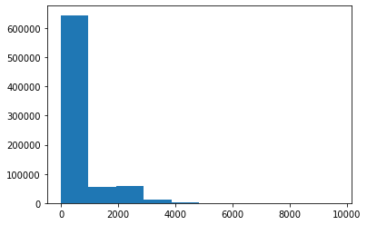

```python
pet_img_data = pet_img.get_fdata()
flatten_data_pet = np.ndarray.flatten(pet_img_data)
plt.hist(flatten_data_pet)
plt.show()
```

Por último, mostraremos unas slices de la PET que hemos cargado.

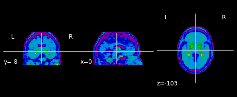

```python
plotting.plot_epi(pet_img)
plotting.show()
```

## Trabajo con T1

En primer lugar, debemos cargar el archivo tal y como hemos hecho con la PET.

```python
t1_img = nib.load(os.path.join(data_path, T1_filename))
t1_header = t1_img.header   # También podemos acceder a los datos del header
t1_data = t1_img.get_fdata()
t1_data.shape
```

```
(196, 256, 256)
```

```python
print('-----Metadatos PET-----')
print('resolución de la imagen: ' + str(pet_img.get_fdata().shape))
print('tamaño del voxel: ' + str(pet_img.header.get_zooms()))
print()

print('-----Metadatos T1-----')
print('resolución de la imagen: ' + str(t1_img.get_fdata().shape))
print('tamaño del voxel: ' + str(t1_img.header.get_zooms()))
```

```
-----Metadatos PET-----
resolución de la imagen: (128, 128, 47)
tamaño del voxel: (2.734375, 2.734375, 3.2700043)

-----Metadatos T1-----
resolución de la imagen: (196, 256, 256)
tamaño del voxel: (1.2, 1.0547, 1.0547)
```

Como podemos observar, el T1 tiene más resolución que la PET, y por lo tanto, para un mismo volumen, usa voxels más pequeños.

A continuación mostramos un histograma con las intensidades que presenta el T1

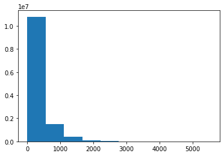

```python
t1_img_data = t1_img.get_fdata()
flatten_data_t1 = np.ndarray.flatten(t1_img_data)
plt.hist(flatten_data_t1)
plt.show()
```

Realizamos el plot del T1

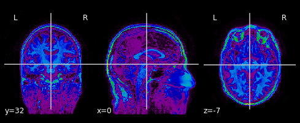

```python
plotting.plot_epi(t1_img)
plotting.show()
```

Por último, vamos a ver el contenido de la máscara

```python
mask = nib.load(os.path.join(data_path, Mask_filename))
mask_header = mask.header
mask_data = mask.get_fdata()
mask_data.shape
```

```
(196, 256, 256)
```

Realizamos el plot de la máscara. En este caso, podemos observar que la máscara está generada sobre la materia gris.

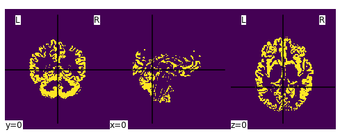

```python
coordinates = (0,0,0)   # Podemos especificar unas coordenadas concretas para hacer las slices
plotting.plot_img(mask, coordinates)    # Esta es la función que usamos para hacer los plots de imagenes en general que no requieren presets
plotting.show()
```

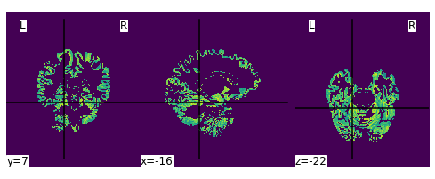

```python
masked = [x*y for x,y in zip(t1_data, mask_data)]   # Lista de comprensión con iteración sobre dos estructuras a la vez
masked = np.reshape(masked, t1_data.shape)
masked_image = nib.Nifti1Image(masked, t1_img.affine, t1_img.header) #Con esta función creamos una nueva imagen a partir de los datos, header y affine que pasamos como parametro
plotting.plot_img(masked_image)
plotting.show()
```

A continuación mostramos el histograma de los distintos valores que presenta la máscara.

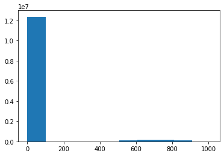

```python
flatten_data_masked = np.ndarray.flatten(masked)
plt.hist(flatten_data_masked)
plt.show()
```

## Pasamos a trabajar con el atlas

```python
atlas_img = nib.load(os.path.join(data_path, Atlas_filename))
atlas_header = atlas_img.header
atlas_data = atlas_img.get_fdata()
atlas_data.shape
```

```
(196, 256, 256)
```

Como los tags del atlas en realidad son valores discretos, en este caso plantearemos un grafico de barras.

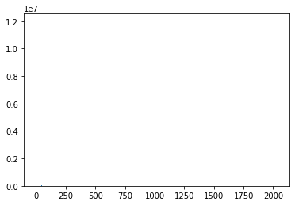

```python
differents = np.unique(atlas_data)
dict = {i: t1_data[atlas_data==i] for i in differents}
count = {i: len(dict[i]) for i in differents}

plt.bar(differents, count.values())
plt.show()
```

Como podemos apreciar en el gráfico, la diferencia en el valor de los contages es tan alta que apenas se pueden apreciar las barras, de modo que plantearemos el mismo gráfico con valores logaritmicos.

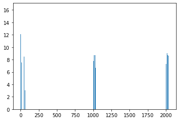

```python
logs = [math.log(x) for x in count.values()]
plt.bar(differents, logs)
plt.show()
```

Ahora vamos a plotear el atlas encima de nuestra imagen original T1

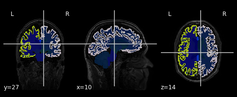

```python
plotting.plot_roi(atlas_img, t1_img)
plotting.show()
```

Podemos hacer lo mismo superponiendo la PET a la T1 y disminuyendo su transparencia.

Sin embargo, como podemos ver, debemos aplicar una corrección en el sistema de coordenadas.

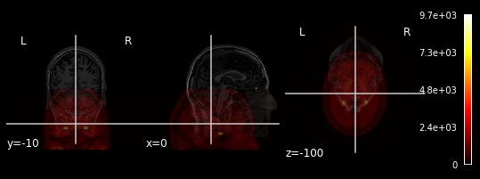

```python
plotting.plot_stat_map(pet_img, t1_img, alpha=0.3)
plotting.show()
```

En este caso, vamos a aplicar la disminución de transparencia a la vez que un threshold de manera que solo nos muestre los puntos de la PET donde el valor de intensidad es superior a 2000.

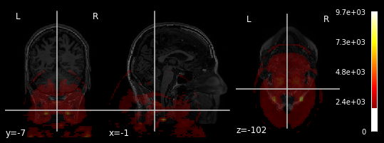

```python
plotting.plot_stat_map(pet_img, t1_img, alpha=0.3, threshold=2000)
plotting.show()
```

Para cada una de las ROI del atlas, vamos a calcular el valor medio de las intensidades de la T1.

```python
dict = {i: t1_data[atlas_data==i] for i in differents}  # Diccionario con todos los valores del atlas como claves y las intensidades de la imagen correspondientes como valores

average_intensities = {i: np.mean(dict[i]) for i in differents} # Diccionario con todos los valores del atlas como claves y las medias de las intensidades de la imagen correspondientes como valores

average_intensities
```

```
{0.0: 149.33306620586862,
 2.0: 1055.179085618232,
 4.0: 250.75123372833934,
 5.0: 373.4678056929922,
 7.0: 1026.4420324006255,
 8.0: 612.4496111984123,
 10.0: 940.3808751253941,
 11.0: 865.4968593801897,
 12.0: 895.1402222064161,
 13.0: 1087.7968904488985,
 14.0: 376.8121594605867,
 15.0: 326.34992704927856,
 16.0: 1054.5069261895767,
 17.0: 740.4232757893253,
 18.0: 805.5351902956219,
 24.0: 425.64272543289877,
 26.0: 808.1912330140459,
 28.0: 1073.590039434023,
 30.0: 659.131831577846,
 31.0: 554.2241477584294,
 41.0: 1055.2894188795192,
 43.0: 255.39957135873595,
 44.0: 308.36443932564396,
 46.0: 1077.062116150757,
 47.0: 676.3521343851161,
 49.0: 953.0904141474605,
 50.0: 854.6759201232095,
 51.0: 875.9633456323414,
 52.0: 1093.963838625087,
 53.0: 730.7481652607339,
 54.0: 806.5941257172527,
 58.0: 834.5483293468154,
 60.0: 1072.6709335382036,
 62.0: 582.6153363314542,
 63.0: 555.4648776255863,
 77.0: 809.842677613586,
 85.0: 1012.8300270547672,
 251.0: 1164.0698007761814,
 252.0: 967.7528561134815,
 253.0: 1047.6950279198256,
```

[output cut: 55 more lines]

```
 2021.0: 781.5549744411534,
 2022.0: 687.4067127775265,
 2023.0: 708.5893807502775,
 2024.0: 666.8639127637372,
 2025.0: 720.9988491978099,
 2026.0: 685.9709211911054,
 2027.0: 679.8619997715072,
 2028.0: 651.5499882790602,
 2029.0: 723.0184201092277,
 2030.0: 680.5147080034698,
 2031.0: 654.3192830447194,
 2032.0: 816.8830820333347,
 2033.0: 687.4226973760186,
 2034.0: 770.5242335247171,
 2035.0: 652.881402597262}
```

Y por último, vamos a guardar el diccionario que hemos creado previamente en un archivo csv

```python
with open('media_intensidades_roi.csv', 'w') as out:
    writer = csv.writer(out)
    writer.writerow(['ROI', 'Media'])
    for key, value in average_intensities.items():
        writer.writerow([key, value])
```